# Fort Collins Water-Demand Data Audit

Acquisition, validation, coverage, and modeling-readiness review

Author

Colin Furey

Published

August 3, 2026

## Purpose

This report audits the data used in the municipal water-demand forecasting project before model development. It verifies provenance and integrity, summarizes temporal and variable coverage, examines basic distributions and relationships, and records limitations that should guide downstream feature engineering and evaluation.

The audit is generated from committed repository artifacts rather than from manually entered summary values. Re-rendering this document after the data pipeline changes will update its tables and figures automatically.

## Executive summary

Table 1: Audit status and processed-dataset summary

|  | Audit item | Result |
| --- | --- | --- |
| 0 | Raw validation status | pass_with_warnings |
| 1 | Validation checks | 43 |
| 2 | Validation errors | 0 |
| 3 | Validation warnings | 1 |
| 4 | Processed rows | 2282 |
| 5 | Processed columns | 17 |
| 6 | Earliest date | 2020-01-01 |
| 7 | Latest date | 2026-03-31 |
| 8 | Missing values | 0 |
| 9 | Duplicate dates | 0 |
| 10 | Missing calendar dates | 0 |
| 11 | Processed SHA-256 | ce30317b66db5075320f3ebb409d6f165f185c965cd73b... |

**TipReadiness determination**

The validated and processed data are suitable for exploratory analysis and time-series model development. The only saved warning concerns the optional NOAA wind variable (`AWND`), which has incomplete raw coverage and is excluded from the initial processed dataset.

Table 2: Non-passing raw-data validation checks

|  | Check | Status | Message |
| --- | --- | --- | --- |
| 0 | noaa_weather.AWND.coverage | warning | Optional variable AWND has 83.26% coverage. |

## Data provenance and lineage

The processed table is built only after the raw snapshots pass the saved cross-source validation report. Each raw and processed file is accompanied by metadata containing its retrieval or generation time, row count, schema, and SHA-256 checksum.

Table 3: Data lineage recorded by acquisition and processing metadata

|  | Stage | Provider | Dataset | File | Rows | Retrieved/generated | SHA-256 |
| --- | --- | --- | --- | --- | --- | --- | --- |
| 0 | Raw water demand | City of Fort Collins Utilities | City of Fort Collins Water Demand | data/raw/water_demand/fort_collins_water_deman... | 2282 | 2026-08-03T16:38:21.967762+00:00 | 63f37f599adaf6f929111a5b0721122eadd5e06357e84c... |
| 1 | Raw NOAA weather | NOAA National Centers for Environmental Inform... | Daily Summaries | data/raw/noaa/noaa_daily_USC00053005_2026-08-0... | 2282 | 2026-08-03T17:00:17.165042+00:00 | 91d8029f3c81c8517b3e553222a921b047eb5b1d5c0402... |
| 2 | Processed daily table | Derived from validated raw snapshots | Fort Collins daily water demand and weather | data/processed/fort_collins_daily_water_weathe... | 2282 | 2026-08-03T17:30:55.484862+00:00 | ce30317b66db5075320f3ebb409d6f165f185c965cd73b... |

### Join integrity

Table 4: One-to-one daily join summary

|  | Join item | Result |
| --- | --- | --- |
| 0 | Join method | inner |
| 1 | Validation rule | one_to_one |
| 2 | Water input rows | 2282 |
| 3 | Weather input rows | 2282 |
| 4 | Output rows | 2282 |
| 5 | Unmatched rows | 0 |
| 6 | Exact raw-date match | True |

## Schema and modeling roles

The primary modeling target is `water_demand_mgd`. The City’s projected demand, the actual-to-projected ratio, and plant demand are retained for auditing and context but are not default predictors. Their availability at a genuine forecast origin would need to be established before they could be used as features.

Table 5: Processed data dictionary

|  | Column | Role | Description | Units | Pandas dtype | Missing values |
| --- | --- | --- | --- | --- | --- | --- |
| 0 | date | Index | Local calendar date. | — | datetime64[ns] | 0 |
| 1 | water_demand_mgd | Target | Observed City water demand; initial forecastin... | million gallons per day | float64 | 0 |
| 2 | projected_water_demand_mgd | Reference | City-provided projected demand; retained as a ... | million gallons per day | float64 | 0 |
| 3 | actual_projected_demand_ratio | Reference | Observed demand divided by projected demand. | — | float64 | 0 |
| 4 | plant_demand_mgd | Reference | Reported treatment-plant demand; retained as a... | million gallons per day | float64 | 0 |
| 5 | tmax_f | Weather feature | Daily maximum air temperature. | degrees Fahrenheit | int64 | 0 |
| 6 | tmin_f | Weather feature | Daily minimum air temperature. | degrees Fahrenheit | int64 | 0 |
| 7 | tavg_f | Derived weather feature | Arithmetic mean of daily maximum and minimum t... | degrees Fahrenheit | float64 | 0 |
| 8 | temperature_range_f | Derived weather feature | Daily maximum minus daily minimum temperature. | degrees Fahrenheit | int64 | 0 |
| 9 | precipitation_in | Weather feature | Daily precipitation. | inches | float64 | 0 |
| 10 | snowfall_in | Weather feature | Daily snowfall. | inches | float64 | 0 |
| 11 | snow_depth_in | Weather feature | Snow depth. | inches | int64 | 0 |
| 12 | year | Calendar feature | Calendar year. | — | int64 | 0 |
| 13 | month | Calendar feature | Calendar month, 1 through 12. | — | int64 | 0 |
| 14 | day_of_year | Calendar feature | Calendar day of year, 1 through 366. | — | int64 | 0 |
| 15 | day_of_week | Calendar feature | Monday=0 through Sunday=6. | — | int64 | 0 |
| 16 | is_weekend | Calendar feature | One for Saturday or Sunday; zero otherwise. | — | int64 | 0 |

## Coverage and completeness

### Daily calendar coverage

Table 6: Number of observations by calendar year

|  | year | first_date | last_date | observations |
| --- | --- | --- | --- | --- |
| 0 | 2020 | 2020-01-01 | 2020-12-31 | 366 |
| 1 | 2021 | 2021-01-01 | 2021-12-31 | 365 |
| 2 | 2022 | 2022-01-01 | 2022-12-31 | 365 |
| 3 | 2023 | 2023-01-01 | 2023-12-31 | 365 |
| 4 | 2024 | 2024-01-01 | 2024-12-31 | 366 |
| 5 | 2025 | 2025-01-01 | 2025-12-31 | 365 |
| 6 | 2026 | 2026-01-01 | 2026-03-31 | 90 |

The final year is a partial year ending March 31, 2026. Annual comparisons must therefore avoid treating 2026 as a complete calendar year.

### Raw NOAA variable coverage

Table 7: Coverage of requested NOAA variables in the raw station file

|  | Variable | present | nonmissing_count | missing_count | coverage_percent |
| --- | --- | --- | --- | --- | --- |
| 1 | PRCP | True | 2282 | 0 | 100.00 |
| 2 | SNOW | True | 2282 | 0 | 100.00 |
| 3 | SNWD | True | 2282 | 0 | 100.00 |
| 4 | TMAX | True | 2282 | 0 | 100.00 |
| 5 | TMIN | True | 2282 | 0 | 100.00 |
| 0 | AWND | True | 1900 | 382 | 83.26 |

`AWND` is preserved in the raw NOAA snapshot but excluded from the processed table because its 83.26% coverage would introduce missingness into the first analysis-ready dataset. No wind imputation is performed at this stage.

## Water-demand characteristics

### Daily series

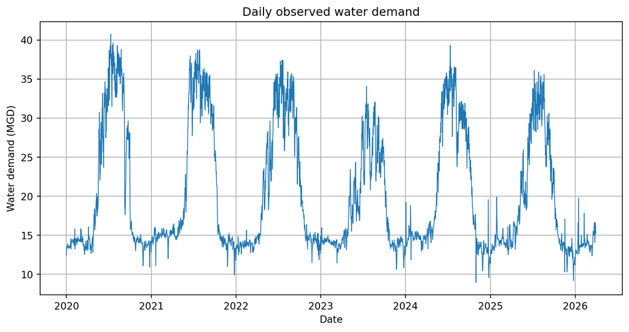

Figure 1: Daily observed Fort Collins water demand over the available period.

### Distribution

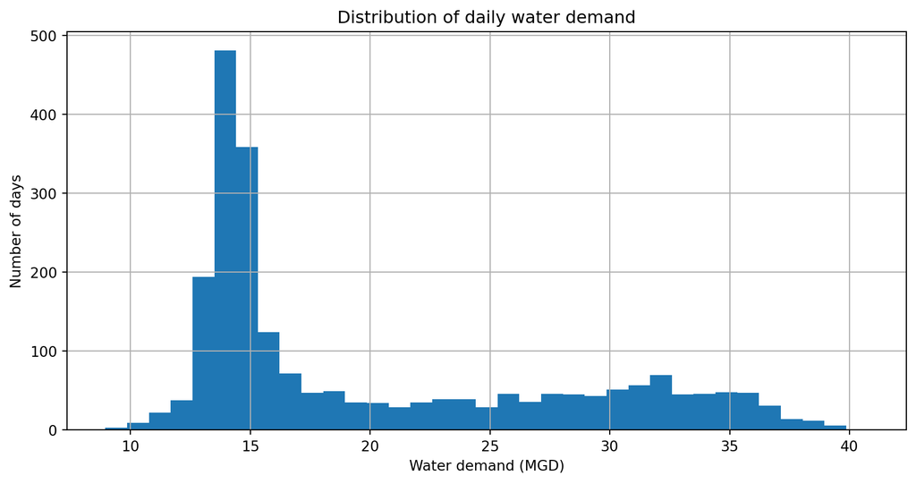

Figure 2: Distribution of daily observed water demand.

### Annual descriptive statistics

Table 8: Annual descriptive statistics for observed water demand

|  | year | count | mean | std | min | median | max |
| --- | --- | --- | --- | --- | --- | --- | --- |
| 0 | 2020 | 366 | 20.928 | 9.077 | 10.94 | 14.805 | 40.77 |
| 1 | 2021 | 365 | 21.272 | 8.682 | 9.93 | 15.730 | 38.79 |
| 2 | 2022 | 365 | 21.121 | 8.040 | 11.49 | 17.410 | 37.43 |
| 3 | 2023 | 365 | 18.490 | 5.698 | 10.63 | 15.340 | 34.10 |
| 4 | 2024 | 366 | 21.013 | 8.113 | 8.95 | 16.325 | 39.34 |
| 5 | 2025 | 365 | 19.486 | 7.126 | 9.21 | 16.200 | 36.09 |
| 6 | 2026 | 90 | 13.979 | 1.239 | 11.18 | 13.725 | 19.77 |

### Monthly seasonal profile

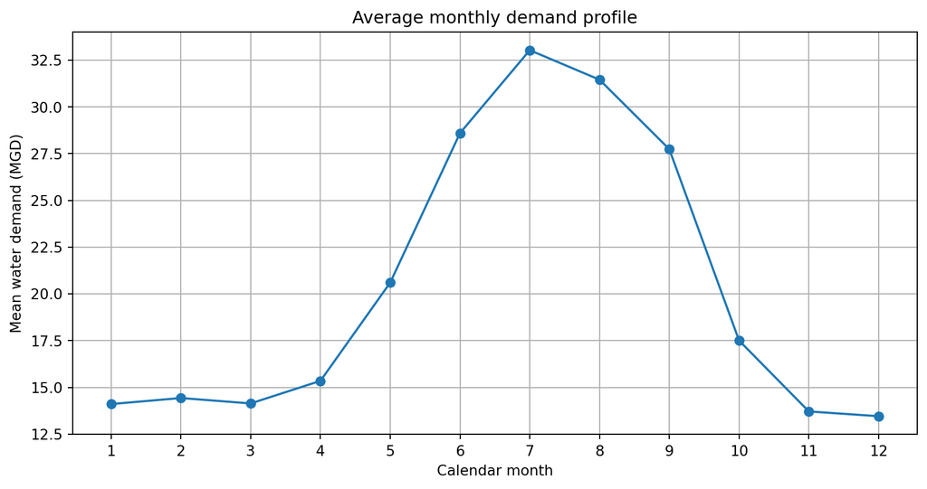

Figure 3: Mean observed water demand by calendar month across the available years.

Table 9: Monthly water-demand summary

|  | month | Mean MGD | Median MGD | Standard deviation | Days |
| --- | --- | --- | --- | --- | --- |
| 0 | 1 | 14.109 | 14.010 | 1.202 | 217 |
| 1 | 2 | 14.431 | 14.355 | 0.629 | 198 |
| 2 | 3 | 14.141 | 14.040 | 0.876 | 217 |
| 3 | 4 | 15.348 | 15.050 | 1.605 | 180 |
| 4 | 5 | 20.603 | 19.880 | 3.610 | 186 |
| 5 | 6 | 28.596 | 30.050 | 5.566 | 180 |
| 6 | 7 | 33.032 | 33.470 | 3.877 | 186 |
| 7 | 8 | 31.453 | 32.100 | 4.087 | 186 |
| 8 | 9 | 27.736 | 27.860 | 3.768 | 180 |
| 9 | 10 | 17.502 | 16.475 | 3.431 | 186 |
| 10 | 11 | 13.713 | 13.900 | 1.090 | 180 |
| 11 | 12 | 13.459 | 13.680 | 1.211 | 186 |

### Weekday and weekend summary

Table 10: Observed demand on weekdays and weekends

|  | day_type | count | mean | median | std |
| --- | --- | --- | --- | --- | --- |
| 0 | Weekday | 1630 | 20.360 | 15.690 | 8.057 |
| 1 | Weekend | 652 | 19.564 | 15.215 | 7.368 |

These comparisons are descriptive. They do not isolate causal calendar effects from weather, seasonality, long-term changes, or serial dependence.

## Weather characteristics

Table 11: Descriptive statistics for processed weather variables

|  | Variable | count | mean | std | min | 25% | 50% | 75% | max |
| --- | --- | --- | --- | --- | --- | --- | --- | --- | --- |
| 0 | tmax_f | 2282.0 | 65.982 | 18.824 | 0.0 | 52.0 | 67.0 | 82.0 | 102.00 |
| 1 | tmin_f | 2282.0 | 37.179 | 16.327 | -17.0 | 25.0 | 37.0 | 52.0 | 74.00 |
| 2 | tavg_f | 2282.0 | 51.580 | 17.037 | -8.5 | 38.5 | 51.5 | 66.5 | 84.50 |
| 3 | temperature_range_f | 2282.0 | 28.803 | 8.987 | 4.0 | 22.0 | 29.0 | 36.0 | 57.00 |
| 4 | precipitation_in | 2282.0 | 0.039 | 0.156 | 0.0 | 0.0 | 0.0 | 0.0 | 2.45 |
| 5 | snowfall_in | 2282.0 | 0.125 | 0.769 | 0.0 | 0.0 | 0.0 | 0.0 | 16.80 |
| 6 | snow_depth_in | 2282.0 | 0.301 | 1.156 | 0.0 | 0.0 | 0.0 | 0.0 | 18.00 |

### Temperature and demand

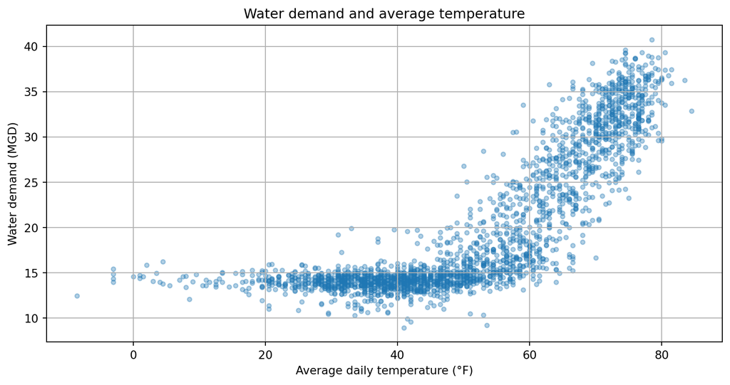

Figure 4: Observed water demand versus average daily temperature. The relationship is descriptive and retains seasonal and temporal confounding.

Table 12: Descriptive Pearson correlations with observed water demand

|  | Variable | Correlation with water demand |
| --- | --- | --- |
| 0 | tavg_f | 0.826 |
| 1 | tmin_f | 0.810 |
| 2 | tmax_f | 0.793 |
| 3 | temperature_range_f | 0.189 |
| 4 | precipitation_in | -0.028 |
| 5 | snowfall_in | -0.135 |
| 6 | snow_depth_in | -0.207 |

The correlations above are exploratory associations, not estimates of causal weather effects. Seasonality, trends, repeated observations, and delayed responses can influence the values.

## City projection reference fields

The source contains both observed and City-projected demand. The project keeps the projected series as a reference for understanding the source data, but it is not included among the default forecasting predictors.

Table 13: Descriptive comparison of observed and City-projected demand

|  | Metric | Value |
| --- | --- | --- |
| 0 | Mean observed demand (MGD) | 20.1329 |
| 1 | Mean projected demand (MGD) | 21.0584 |
| 2 | Mean observed-minus-projected error (MGD) | -0.9255 |
| 3 | Mean absolute error (MGD) | 1.9535 |
| 4 | Root mean squared error (MGD) | 3.0162 |
| 5 | Observed/projected correlation | 0.9368 |

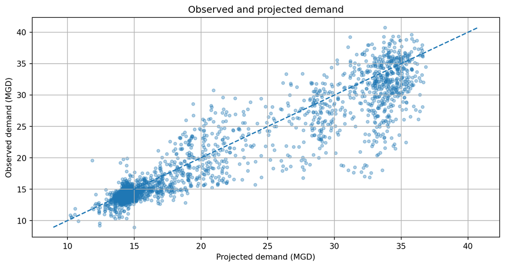

Figure 5: Observed versus City-projected daily demand. The diagonal represents equality.

## Deterministic transformation checks

The processed builder creates several deterministic fields. This report rechecks their identities rather than assuming they were generated correctly.

Table 14: Independent checks of derived columns

|  | Check | Mismatches |
| --- | --- | --- |
| 0 | tavg_f = (tmax_f + tmin_f) / 2 | 0 |
| 1 | temperature_range_f = tmax_f - tmin_f | 0 |
| 2 | year matches date | 0 |
| 3 | month matches date | 0 |
| 4 | day_of_year matches date | 0 |
| 5 | day_of_week uses Monday=0 | 0 |
| 6 | is_weekend matches Saturday/Sunday | 0 |

## Modeling-readiness considerations

**WarningTime-series leakage**

Random train/test splits are not appropriate for the primary evaluation. Validation should preserve chronological order through a fixed holdout, rolling-origin evaluation, or another explicitly time-aware design.

The following decisions should carry into model development:

1. **Target.** Use `water_demand_mgd` as the initial outcome. Continue treating the City projection, observed/projected ratio, and plant demand as reference columns unless their real-time availability and intended interpretation are established.
2. **Weather variables.** The first processed table uses complete temperature, precipitation, snowfall, and snow-depth fields. `AWND` remains available in raw data but is excluded rather than silently imputed.
3. **Calendar variables.** Integer month and weekday encodings are convenient audit fields, but some models may need categorical or cyclical representations instead of assuming a linear numeric effect.
4. **Lagged demand features.** Lags and rolling summaries can be useful, but every feature must be computed using only information available before the prediction date. Rolling calculations should be shifted before model fitting.
5. **Partial final year.** The series ends March 31, 2026. Full-year summaries and year-over-year comparisons must account for the incomplete 2026 period.
6. **Single weather station.** The primary station provides complete core coverage, but one station cannot represent every microclimate within the utility service area. This is an explicit scope limitation of the minimum viable analysis.
7. **Source status.** The water-demand data are preserved as a dated raw snapshot because the City’s open-data platform was undergoing migration. Future refreshes should be compared against the current snapshot and accompanied by updated acquisition metadata.

## Audit conclusion

The data pipeline produces a complete one-to-one daily table with verified provenance, matching checksums, no duplicate dates, no missing calendar dates, and no missing processed values. The dataset is approved for the next stage: time-aware exploratory forecasting baselines and feature engineering.

The audit should be re-rendered whenever raw snapshots, source endpoints, station choices, processing rules, or processed outputs change.